# Comparsion among thirteen major schools in philisophy through text mining

Chenghao Lu

2023-01-29

Philosophy is the general study of problems such as reason, values,mind…For people who never learn philosophy before, they may have heard of plato or aristotle but have no idea of what the truth in philosophy is. In this data story, I will give all levels of audience a general picture of philosophy through text mining and visualization from history of philosophy dataset. The dataset consists of sentences from authors in thirteen major schools(“plato”,“aristotle”,“stoicism”,“rationalism”,“empiricism”,“capitalism”,“german_idealism”,“communism”,“nietzsche”,“phenomenology”,“feminism”,“continental”,“analytic”). I will use text mining to look for possible similarities or differences among these schools.

## Part I load libraries

```r
library(beeswarm)
library(dichromat)
library(dplyr)
library(factoextra)
library(fmsb)
library(ggplot2)
library(readtext)
library(rvest)
library(sentimentr)
library(stopwords)
library(stringr)
library(textreuse)
library(tibble)
library(tidytext)
library(tidyverse)
library(tm)
library(topicmodels)
library(wordcloud)
```

## Part II Main Philosophy idea for each school through wordclouds

The first comparison is to find how their main ideas differ or similar from each other through wordclouds. Wordcloud is a powerful visualization tool that can help us understand how frequently each word appears in the corpus by different size of text.The main idea of each school can easily be investigated by visualizing its corresponding wordcloud.

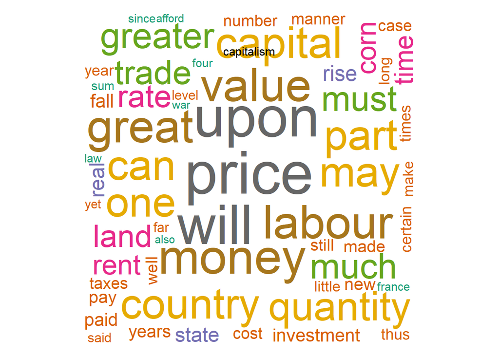

```r
df = read.csv("C:/Users/Chenghao Lu/Desktop/philosophy_data.csv")

sot = c("plato","aristotle","stoicism","rationalism","empiricism","capitalism","german_idealism","communism","nietzsche","phenomenology","feminism","continental","analytic")
typical = c("capitalism","feminism","stoicism","plato","continental")

wc <- function(i){
  docs <- Corpus(VectorSource(df[df$school == i , ]$sentence_str)) %>%
    tm_map(tolower) %>%
    tm_map(removePunctuation) %>%
    tm_map(removeNumbers) %>%
    tm_map(removeWords, stopwords("english")) %>%
    tm_map(stripWhitespace)

  dtm <- TermDocumentMatrix(docs)
  matrix <- as.matrix(dtm)
  words <- sort(rowSums(matrix),decreasing=TRUE)
  return(df2 <- data.frame(word = names(words),freq=words))
}

  capitalism = wc(typical[1])

  wordcloud(words = capitalism$word, freq = capitalism$freq, min.freq = 1,
            scale = c(5,0.5), max.words=200, random.order =   FALSE,colors=brewer.pal(8, "Dark2"))
  mtext("capitalism",side=3)
```

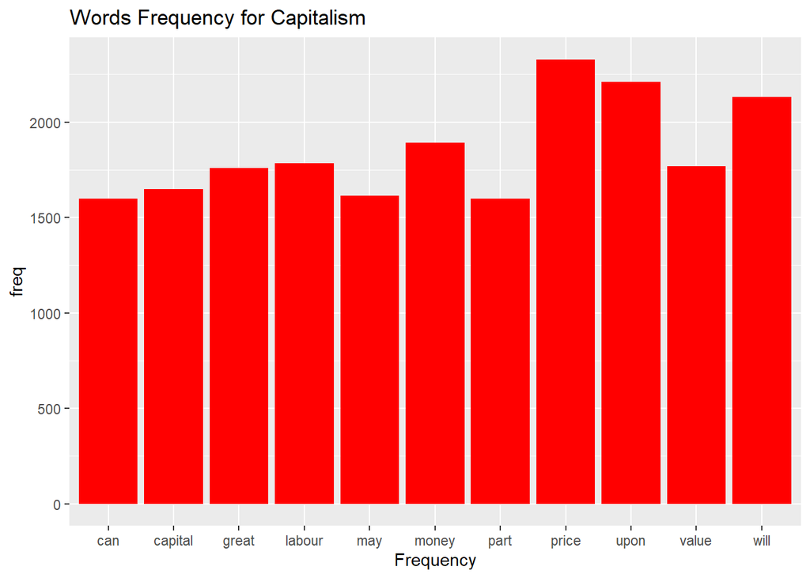

```r
capitalism %>% filter(freq>1595) %>%  ggplot() +
  geom_col(aes(x = word, y = freq), fill = "red") +
  labs(x = "Frequency", title = "Words Frequency for Capitalism")
```

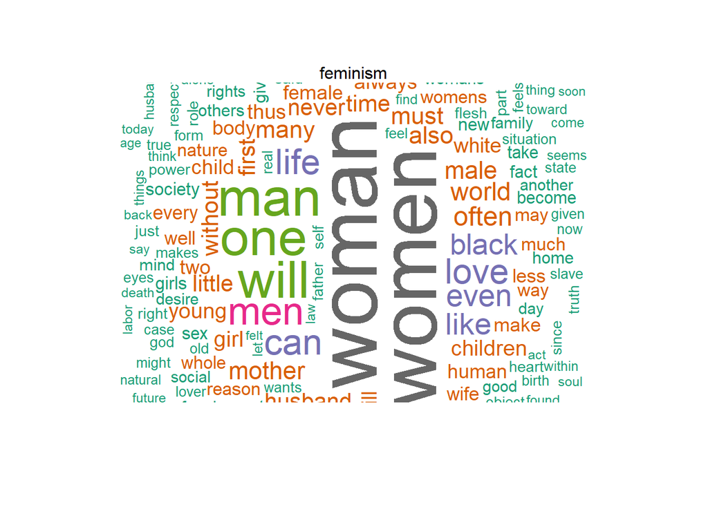

```r
feminism = wc(typical[2])
wordcloud(words = feminism$word, freq = feminism$freq, min.freq = 1,
            scale = c(5,0.5), max.words=200, random.order =   FALSE,colors=brewer.pal(8, "Dark2"))
  mtext("feminism",side=3)
```

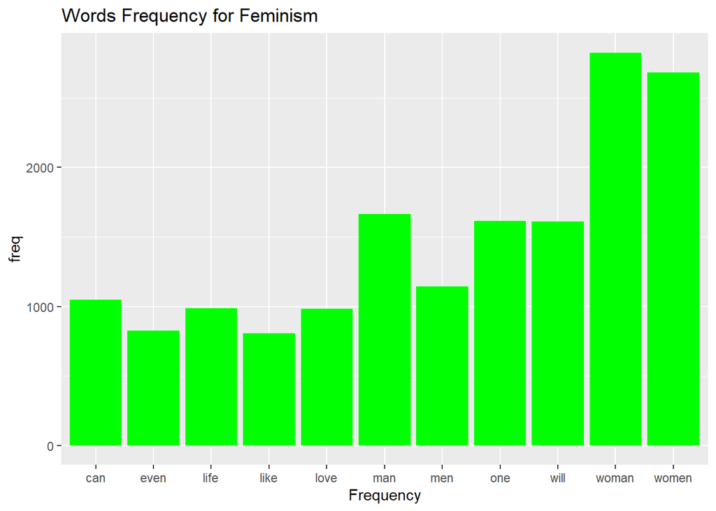

```r
feminism %>% filter(freq>800) %>%  ggplot() +
  geom_col(aes(x = word, y = freq), fill = "green") +
  labs(x = "Frequency", title = "Words Frequency for Feminism")
```

By examining the wordclouds and bar plots, some themes from particular school become obvious. For capitalism, the words like “price”,“value”,“money” appear more often than other words which implies that this school focuses more on economics. Similar for feminism, the words like “woman”, “man” reflect its focus on woman’s rights and the words such as “black”,“white” also infer its study on racial discrimination.

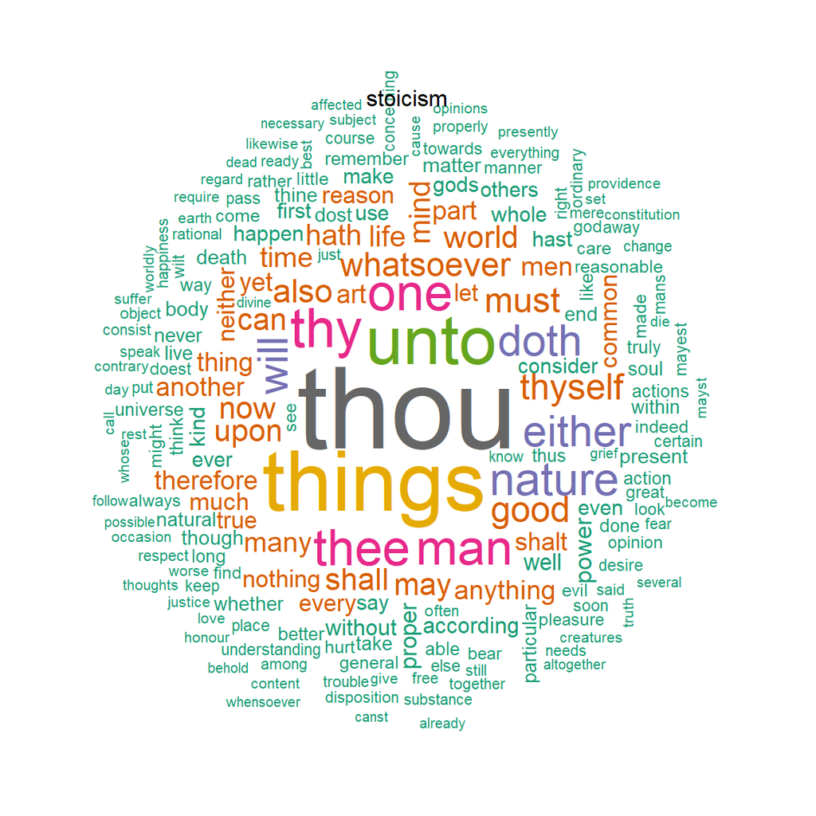

```r
sto = wc(typical[3])
wordcloud(words = sto$word, freq = sto$freq, min.freq = 1,
            scale = c(5,0.5), max.words=200, random.order =   FALSE,colors=brewer.pal(8, "Dark2"))
  mtext("stoicism",side=3)
```

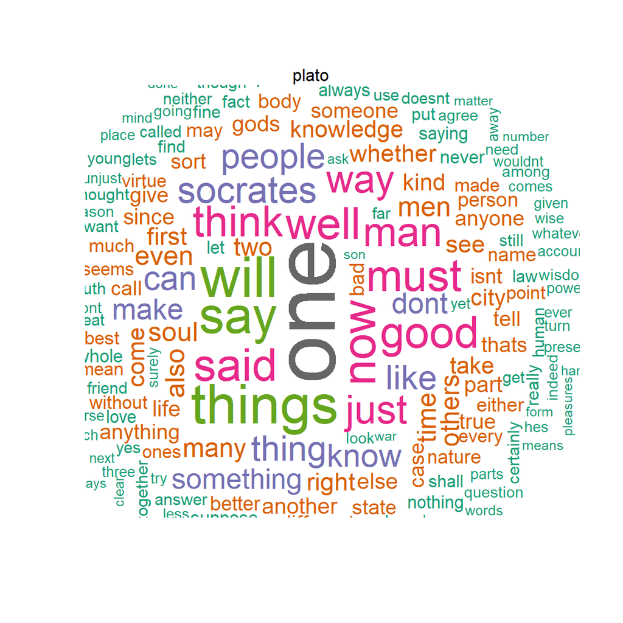

```r
plato = wc(typical[4])
wordcloud(words = plato$word, freq = plato$freq, min.freq = 1,
            scale = c(5,0.5), max.words=200, random.order =   FALSE,colors=brewer.pal(8, "Dark2"))
  mtext("plato",side=3)
```

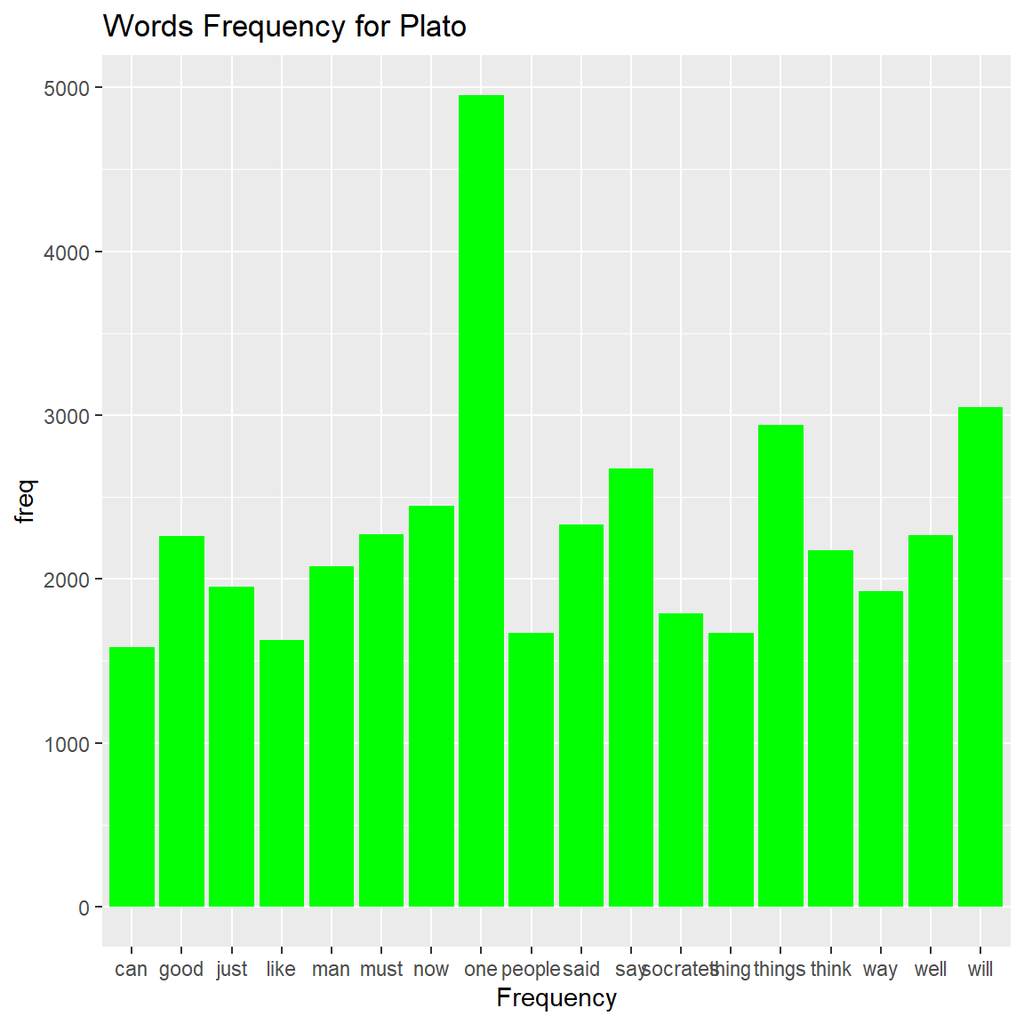

```r
plato %>% filter(freq>1500) %>%  ggplot() +
  geom_col(aes(x = word, y = freq), fill = "green") +
  labs(x = "Frequency", title = "Words Frequency for Plato")
```

However, sometimes wordcloud is not enough to see the main idea behind. For example, the stoicism uses old Engligh a lot in the text and it is difficult to understand the meaning by just counting the frequency of each word. Also, themes from some schools like Plato … are possibly too abstract to visualize through wordclouds because we can only see the words like “one”,“thing”,“can”. In this case, we had better read the whole context to understand the meaning behind the words.

## Part III NRC Sentiment analysis for each school

It is also interesting to find the emotions behind the words for each school. There are eight basic sentiments mentioned in NRC lexicon(anger,anticipation,disgust,fear,joy,sadness,surprise,trust). By simply inner join and analyzing the sentiment value, we can find the extent of appearance of certain emotional aspects in philosophical expressions.

```r
emo <- get_sentiments("nrc") %>% filter(sentiment != "positive" & sentiment != "negative")
text <- tibble(author = df$author, school = df$school, text = df$lemmatized_str)
tokenized <- text %>% unnest_tokens(word, text)
tidy_words <- tokenized %>% anti_join(stop_words) %>% filter(word != "pron")

text_tokenized <- tidy_words %>% inner_join(emo)
text_tokenized = count(text_tokenized, school, sentiment)
text_tokenized
```

```
## # A tibble: 104 × 3
##    school    sentiment        n
##    <chr>     <chr>        <int>
##  1 analytic  anger        11870
##  2 analytic  anticipation 23121
##  3 analytic  disgust       7124
##  4 analytic  fear         14289
##  5 analytic  joy          11666
##  6 analytic  sadness      12422
##  7 analytic  surprise      8317
##  8 analytic  trust        42095
##  9 aristotle anger        17725
## 10 aristotle anticipation 25686
## # … with 94 more rows
```

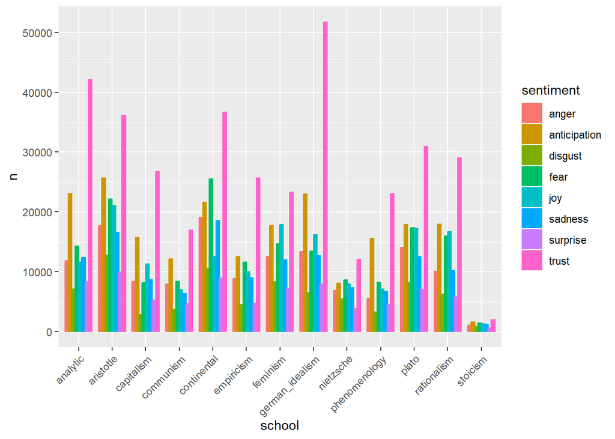

```r
ggplot(text_tokenized, aes(x = school, y = n)) +
  geom_bar(
    aes(color = sentiment, fill = sentiment),
    stat = "identity", position = position_dodge(0.8)
    ) +theme(axis.text.x = element_text(angle = 45, vjust = 1, hjust = 1))
```

Interestingly, from the above graph, “trust” seems to be the most frequent emotions in philosophical expressions because it occupies the most part in bars for all schools while disgust and surprise are the least popular emotions among them. This can possibly be explained by the fact that all authors, no matter from which school, hope to utilize some “trust” words instead of disgusting or surprising words to deliver their ideas and convince audience.

### 3.1 Sentiment analysis for each author

```r
pn <- get_sentiments("nrc") %>% filter(sentiment == "positive" | sentiment == "negative")

text_tokenized_2 <- tidy_words %>% inner_join(pn)
text_tokenized_2 = count(text_tokenized_2, author, sentiment)
text_tokenized_2
```

```
## # A tibble: 72 × 3
##    author    sentiment     n
##    <chr>     <chr>     <int>
##  1 Aristotle negative  40224
##  2 Aristotle positive  65260
##  3 Beauvoir  negative  18010
##  4 Beauvoir  positive  25507
##  5 Berkeley  negative   2004
##  6 Berkeley  positive   4621
##  7 Davis     negative   4338
##  8 Davis     positive   5127
##  9 Deleuze   negative  12140
## 10 Deleuze   positive  18637
## # … with 62 more rows
```

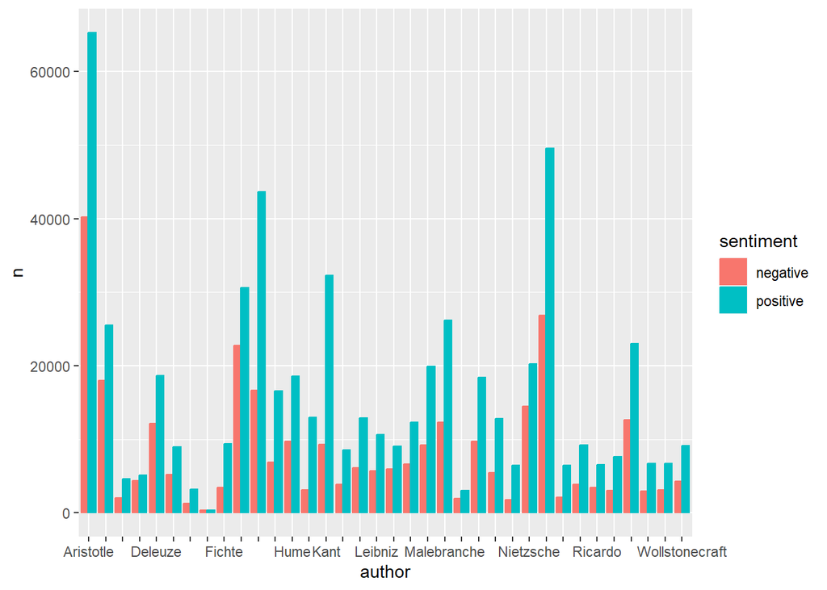

```r
ggplot(text_tokenized_2, aes(x = author, y = n)) +geom_bar(aes(color = sentiment, fill = sentiment),
    stat = "identity", position = position_dodge(0.8))+scale_x_discrete(guide = guide_axis(check.overlap = TRUE))
```

In a similar way, we can check if the words are positive or negative for each author. The barplot above shows that for each author, no matter from which school, prefer to use positive words rather than negative one.

## Part IV sentence length comparison for each school

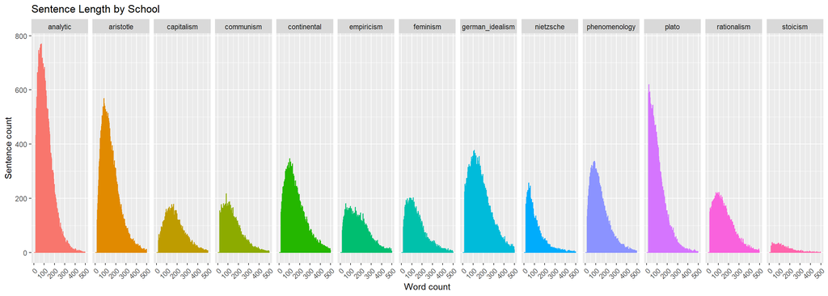

```r
df <- mutate(df,school_new =factor(school))


ggplot(df,aes(x = sentence_length,color=school_new,fill=school_new)) +geom_histogram(binwidth = 2, show.legend = FALSE)+xlim(0,500)+ facet_grid(.~school)+ labs(title = "Sentence Length by School", x = "Word count", y = "Sentence count")+theme(axis.text.x = element_text(angle = 45, vjust = 1, hjust = 1))
```

## Part V Conclusion

So far we have made comparisons of each school through text mining in three different aspects.